# Spread Model

The `SpreadModels` module provides composable, differentiable components for driving level set fire simulations. Instead of manually constructing a spread rate matrix `F`, you build a `RothermelModel` from pluggable wind, moisture, and terrain components — each a callable `(t, x, y)` struct.

## Architecture

```
RothermelModel(fuel, wind, moisture, terrain)
       │
       ▼
model(t, x, y) → rate_of_spread(fuel; moisture, wind, slope)
       │
       ▼
simulate!(grid, model) → level set evolution
```

Each component is a callable struct with signature `(t, x, y)`:

| Component | Returns | Example |
| --- | --- | --- |
| `wind::AbstractWind` | `(speed, direction)` — speed [km/h], direction [radians] | `UniformWind(speed=8.0)` |
| `moisture::AbstractMoisture` | `FuelClasses` — moisture fractions | `UniformMoisture(...)` |
| `terrain::AbstractTerrain` | `(slope, aspect)` — slope [fraction], aspect [radians] | `FlatTerrain()` |

## Quick Example

```julia
M = FuelClasses(d1=0.06, d10=0.07, d100=0.08, herb=0.0, wood=0.0)

model = RothermelModel(
    SHORT_GRASS,
    UniformWind(speed=8.0),
    UniformMoisture(M),
    FlatTerrain()
)

# Evaluate spread rate at a single point
model(0.0, 100.0, 100.0)
```

```
31.119112730486354
```

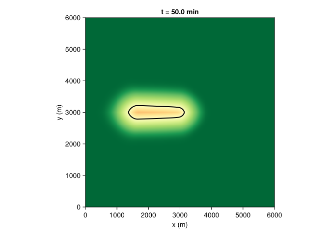

```julia
# Full simulation
grid = LevelSetGrid(200, 200, dx=30.0)
ignite!(grid, 3000.0, 3000.0, 50.0)
simulate!(grid, model, steps=100, dt=0.5)

fig = Figure()
ax = Axis(fig[1, 1], title="t = $(grid.t) min", aspect=DataAspect(),
    xlabel="x (m)", ylabel="y (m)")
fireplot!(ax, grid)
fig
```

## Directional Spread Models

Pass a directional model as the 5th argument to `RothermelModel`:

- `CosineBlending()` (default) — `R(θ) = R_base + (R_head - R_base) · max(0, cos θ)`
- `EllipticalBlending()` — `R(θ) = R_head · (1 - ε) / (1 - ε · cos θ)` where `ε` is fire eccentricity

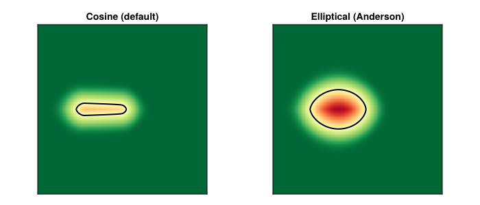

```julia
M = FuelClasses(d1=0.06, d10=0.07, d100=0.08, herb=0.0, wood=0.0)

fig = Figure(size=(700, 300))
for (col, (label, dir)) in enumerate([
    ("Cosine (default)", CosineBlending()),
    ("Elliptical (Anderson)", EllipticalBlending()),
])
    g = LevelSetGrid(200, 200, dx=30.0)
    ignite!(g, 3000.0, 3000.0, 50.0)
    m = RothermelModel(SHORT_GRASS, UniformWind(speed=8.0), UniformMoisture(M), FlatTerrain(), dir)
    simulate!(g, m, steps=100, dt=0.5)
    ax = Axis(fig[1, col], title=label, aspect=DataAspect())
    fireplot!(ax, g)
    hidedecorations!(ax)
end
fig
```

### Length-to-Breadth Formulas

The `EllipticalBlending` model computes a length-to-breadth ratio (LB) from midflame wind speed using a published formula. Two options are available:

- `:anderson` (default) — Anderson (1983), general-purpose
- `:green` — Green (1983), suitable for grass fuels

```julia
EllipticalBlending(formula=:green)  # use Green's formula
```

```
EllipticalBlending(:green)
```

The helper functions `length_to_breadth` and `fire_eccentricity` are exported for use in custom spread models:

```julia
U = 2.0  # m/s midflame wind speed
LB = length_to_breadth(U)
ε = fire_eccentricity(LB)
(LB=LB, ε=ε)
```

```
(LB = 1.5049627492754702, ε = 0.7473164746215192)
```

## Wind

### `UniformWind`

Spatially and temporally constant wind field.

```julia
wind = UniformWind(speed=10.0, direction=π/4)
wind(0.0, 0.0, 0.0)  # (speed, direction)
```

```
(10.0, 0.7853981633974483)
```

## Moisture

### `UniformMoisture`

Spatially and temporally constant fuel moisture.

```julia
moist = UniformMoisture(FuelClasses(d1=0.06, d10=0.07, d100=0.08, herb=0.0, wood=0.0))
moist(0.0, 0.0, 0.0)
```

```
FuelClasses{Float64}(d1=0.06, d10=0.07, d100=0.08, herb=0.0, wood=0.0)
```

### `DynamicMoisture`

Spatially varying fuel moisture that responds to fire-induced drying. As the fire front approaches, radiative heat dries unburned fuel ahead of the front. The 1-hr dead fuel moisture (`d1`) varies spatially while other size classes remain constant.

The drying model at each unburned cell:

$$\frac{dM}{dt} = -\frac{\text{dry\_rate}}{\phi^2 + 1} + \text{recovery\_rate} \cdot (M_{\text{ambient}} - M)$$

where $\phi$ is the level set value (approximate distance to the fire front in meters).

```julia
grid_d = LevelSetGrid(100, 100, dx=30.0)
ignite!(grid_d, 1500.0, 1500.0, 100.0)

M = FuelClasses(d1=0.06, d10=0.07, d100=0.08, herb=0.0, wood=0.0)
dm = DynamicMoisture(grid_d, M, dry_rate=0.1, recovery_rate=0.001)
```

```
DynamicMoisture{Float64, Matrix{Float64}}([0.06 0.06 … 0.06 0.06; 0.06 0.06 … 0.06 0.06; … ; 0.06 0.06 … 0.06 0.06; 0.06 0.06 … 0.06 0.06], FuelClasses{Float64}(d1=0.06, d10=0.07, d100=0.08, herb=0.0, wood=0.0), 0.06, 0.1, 0.001, 0.03, 30.0, 30.0, 0.0, 0.0)
```

**Parameter guidance:**

| Parameter | Default | Typical Range | Effect |
| --- | --- | --- | --- |
| `dry_rate` | `0.1` | `0.01` – `0.5` | How fast fire dries nearby fuel. Higher values = stronger pre-heating effect, faster fire acceleration. |
| `recovery_rate` | `0.001` | `0.0001` – `0.01` | How fast fuel rewets toward ambient. Higher values = fuel recovers quickly when fire moves away. |
| `min_d1` | `0.03` | `0.02` – `0.05` | Minimum 1-hr dead fuel moisture (fraction). Below ~0.03, wildland fuels are essentially oven-dry. |

The `dry_rate` is the most sensitive parameter — it controls the positive feedback loop where fire dries adjacent fuel, increasing spread rate, which dries more fuel. Start with the default (`0.1`) and adjust based on whether the simulated fire accelerates too quickly or too slowly.

Comparing static vs. dynamic moisture:

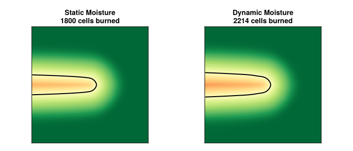

```julia
M = FuelClasses(d1=0.06, d10=0.07, d100=0.08, herb=0.0, wood=0.0)

# Static
grid_s = LevelSetGrid(150, 150, dx=20.0)
ignite!(grid_s, 1500.0, 1500.0, 50.0)
model_s = RothermelModel(SHORT_GRASS, UniformWind(speed=8.0), UniformMoisture(M), FlatTerrain())
simulate!(grid_s, model_s, steps=150, dt=0.5)

# Dynamic
grid_d = LevelSetGrid(150, 150, dx=20.0)
ignite!(grid_d, 1500.0, 1500.0, 50.0)
model_d = RothermelModel(SHORT_GRASS, UniformWind(speed=8.0), DynamicMoisture(grid_d, M), FlatTerrain())
simulate!(grid_d, model_d, steps=150, dt=0.5)

fig = Figure(size=(700, 300))
ax1 = Axis(fig[1, 1], title="Static Moisture\n$(count(<(0), grid_s.φ)) cells burned",
    aspect=DataAspect())
fireplot!(ax1, grid_s)
hidedecorations!(ax1)

ax2 = Axis(fig[1, 2], title="Dynamic Moisture\n$(count(<(0), grid_d.φ)) cells burned",
    aspect=DataAspect())
fireplot!(ax2, grid_d)
hidedecorations!(ax2)
fig
```

## Terrain

### `FlatTerrain`

Zero slope everywhere.

```julia
FlatTerrain()(0.0, 0.0, 0.0)  # (slope, aspect)
```

```
(0.0, 0.0)
```

### `UniformSlope`

Spatially constant terrain slope.

```julia
slope = UniformSlope(slope=0.3, aspect=0.0)
slope(0.0, 0.0, 0.0)
```

```
(0.3, 0.0)
```

Effect of slope on fire spread:

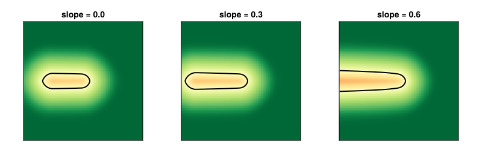

```julia
M = FuelClasses(d1=0.06, d10=0.07, d100=0.08, herb=0.0, wood=0.0)

fig = Figure(size=(800, 250))
for (col, s) in enumerate([0.0, 0.3, 0.6])
    g = LevelSetGrid(150, 150, dx=20.0)
    ignite!(g, 1500.0, 1500.0, 50.0)
    m = RothermelModel(SHORT_GRASS, UniformWind(speed=5.0), UniformMoisture(M), UniformSlope(slope=s))
    simulate!(g, m, steps=150, dt=0.5)
    ax = Axis(fig[1, col], title="slope = $s", aspect=DataAspect())
    fireplot!(ax, g)
    hidedecorations!(ax)
end
fig
```

## Fuel Breaks and Unburnable Areas

The `LevelSetGrid` tracks per-cell ignition state via `t_ignite`. By default all cells are burnable (`t_ignite = Inf`). Cells marked as unburnable have `t_ignite = NaN`, which sets their spread rate to zero.

Use `set_unburnable!` to mark circular regions, or directly set `grid.t_ignite[i, j] = NaN` for arbitrary shapes. The convenience function `burnable(grid)` returns a `BitMatrix` of burnable cells.

This is useful for representing water bodies, roads, fuel breaks, and pre-existing fire scars.

### Creating a Fuel Break

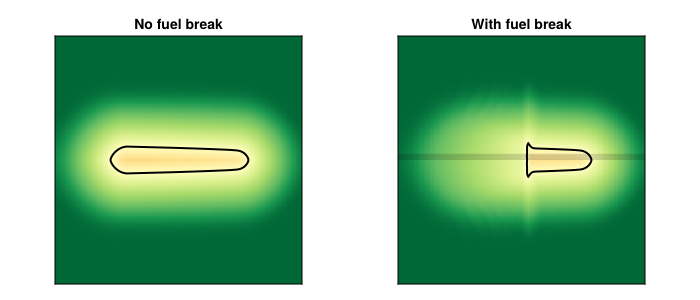

```julia
M = FuelClasses(d1=0.06, d10=0.07, d100=0.08, herb=0.0, wood=0.0)
model = RothermelModel(SHORT_GRASS, UniformWind(speed=8.0), UniformMoisture(M), FlatTerrain())

fig = Figure(size=(700, 300))

# Without fuel break
g1 = LevelSetGrid(200, 200, dx=30.0)
ignite!(g1, 4500.0, 3000.0, 50.0)
simulate!(g1, model, steps=200, dt=0.5)
ax1 = Axis(fig[1, 1], title="No fuel break", aspect=DataAspect())
fireplot!(ax1, g1)
hidedecorations!(ax1)

# With fuel break (strip in the fire's path)
g2 = LevelSetGrid(200, 200, dx=30.0)
ignite!(g2, 4500.0, 3000.0, 50.0)
# Mark columns as unburnable ahead of the fire (lower x = south on plot)
xs = xcoords(g2)
for j in eachindex(xs)
    if 3000.0 <= xs[j] <= 3150.0
        g2.t_ignite[:, j] .= NaN
    end
end
simulate!(g2, model, steps=200, dt=0.5)
ax2 = Axis(fig[1, 2], title="With fuel break", aspect=DataAspect())
fireplot!(ax2, g2)
hspan!(ax2, 3000.0, 3150.0, color=(:black, 0.15))
hidedecorations!(ax2)
fig
```

### Marking Pre-Burned Areas

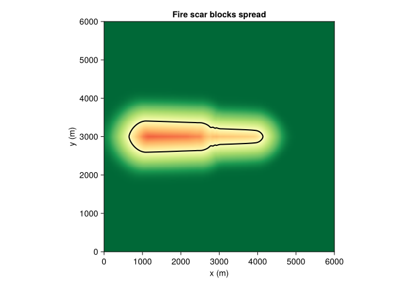

```julia
grid = LevelSetGrid(200, 200, dx=30.0)

# Pre-existing fire scar: set φ < 0 AND mark unburnable
cx, cy, r = 2500.0, 3000.0, 300.0
xs = xcoords(grid)
ys = ycoords(grid)
for j in eachindex(xs), i in eachindex(ys)
    if hypot(xs[j] - cx, ys[i] - cy) <= r
        grid.φ[i, j] = -1.0
    end
end
set_unburnable!(grid, cx, cy, r)

# New ignition away from the scar
ignite!(grid, 4000.0, 3000.0, 50.0)

M = FuelClasses(d1=0.06, d10=0.07, d100=0.08, herb=0.0, wood=0.0)
model = RothermelModel(SHORT_GRASS, UniformWind(speed=8.0), UniformMoisture(M), FlatTerrain())
simulate!(grid, model, steps=100, dt=0.5)

fig = Figure()
ax = Axis(fig[1, 1], title="Fire scar blocks spread", aspect=DataAspect(),
    xlabel="x (m)", ylabel="y (m)")
fireplot!(ax, grid)
fig
```

## Burnout

By default, once a cell ignites it continues to contribute to fire spread indefinitely. In reality, fuel is consumed and the flaming front passes. The `burnout` keyword in `simulate!` models this by scaling the spread rate based on how long a cell has been burning.

Three burnout models are available:

| Type | Formula | Behavior |
| --- | --- | --- |
| `NoBurnout()` | `1.0` | Fire spreads indefinitely (default) |
| `ExponentialBurnout(τ)` | `exp(-t/τ)` | Smooth exponential decay over residence time `τ` |
| `LinearBurnout(τ)` | `max(0, 1 - t/τ)` | Linear ramp to zero over residence time `τ` |

The residence time `τ` is computed from the Rothermel fuel model using Anderson’s (1969) formula:

$$t_r = \frac{384}{\sigma_{\text{char}} \cdot 60} \text{ [min]}$$

where $\sigma_{\text{char}}$ is the characteristic surface-area-to-volume ratio [ft$^{-1}$].

```julia
using Wildfires.Rothermel: residence_time

# Residence time varies by fuel type
(SHORT_GRASS = residence_time(SHORT_GRASS),
 CHAPARRAL = residence_time(CHAPARRAL),
 TIMBER_UNDERSTORY = residence_time(TIMBER_UNDERSTORY))
```

```
(SHORT_GRASS = 0.0018285714285714285, CHAPARRAL = 0.0036797903975260777, TIMBER_UNDERSTORY = 0.003626517214741357)
```

### Using Burnout in Simulation

Pass a burnout model to `simulate!`:

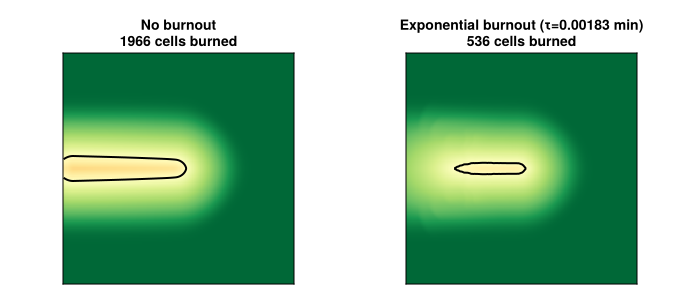

```julia
M = FuelClasses(d1=0.06, d10=0.07, d100=0.08, herb=0.0, wood=0.0)

fig = Figure(size=(700, 300))

# Without burnout
g1 = LevelSetGrid(200, 200, dx=30.0)
ignite!(g1, 3000.0, 3000.0, 50.0)
m1 = RothermelModel(SHORT_GRASS, UniformWind(speed=8.0), UniformMoisture(M), FlatTerrain())
simulate!(g1, m1, steps=200, dt=0.5)
ax1 = Axis(fig[1, 1], title="No burnout\n$(count(<(0), g1.φ)) cells burned", aspect=DataAspect())
fireplot!(ax1, g1)
hidedecorations!(ax1)

# With exponential burnout
g2 = LevelSetGrid(200, 200, dx=30.0)
ignite!(g2, 3000.0, 3000.0, 50.0)
t_r = residence_time(SHORT_GRASS)
simulate!(g2, m1, steps=200, dt=0.5, burnout=ExponentialBurnout(t_r))
ax2 = Axis(fig[1, 2], title="Exponential burnout (τ=$(round(t_r, sigdigits=3)) min)\n$(count(<(0), g2.φ)) cells burned", aspect=DataAspect())
fireplot!(ax2, g2)
hidedecorations!(ax2)
fig
```

**Note**

## Custom Components

To create a custom component, define a callable struct that subtypes `AbstractWind`, `AbstractMoisture`, or `AbstractTerrain`.

For example, a wind field that varies in space:

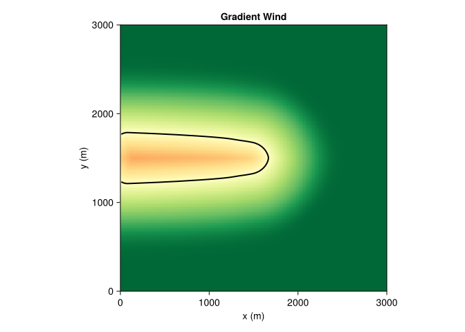

```julia
struct GradientWind <: AbstractWind
    base_speed::Float64
    gradient::Float64   # speed increase per meter in x
end

function (w::GradientWind)(t, x, y)
    speed = w.base_speed + w.gradient * x
    direction = 0.0  # wind from the west
    (speed, direction)
end

M = FuelClasses(d1=0.06, d10=0.07, d100=0.08, herb=0.0, wood=0.0)
g = LevelSetGrid(150, 150, dx=20.0)
ignite!(g, 1500.0, 1500.0, 50.0)
m = RothermelModel(SHORT_GRASS, GradientWind(5.0, 0.003), UniformMoisture(M), FlatTerrain())
simulate!(g, m, steps=150, dt=0.5)

fig = Figure()
ax = Axis(fig[1, 1], title="Gradient Wind", aspect=DataAspect(), xlabel="x (m)", ylabel="y (m)")
fireplot!(ax, g)
fig
```

For dynamic components that respond to fire state, also implement `update!`:

```julia
SpreadModels.update!(w::MyDynamicWind, grid::LevelSetGrid, dt) = ...
```

## Simulation Parameters

The `simulate!` function accepts several keyword arguments that control numerical behavior:

| Parameter | Default | Description |
| --- | --- | --- |
| `steps` | `100` | Number of time steps to run |
| `dt` | `nothing` | Time step in minutes. When `nothing`, computed automatically via the CFL condition each step. |
| `cfl` | `0.5` | Safety factor for the CFL condition (`dt = cfl * min(dx,dy) / max(F)`). Only used when `dt=nothing`. |
| `reinit_every` | `10` | Reinitialization frequency. Every N steps, the level set is restored to a signed distance function. |
| `solver` | `Godunov()` | Numerical solver for the level set equation. See Solvers. |
| `curvature` | `0.0` | Curvature regularization coefficient. When > 0, smooths the fire front via `F_eff = max(F - b·κ, 0)`. See Curvature. |
| `reinit` | `IterativeReinit()` | Reinitialization method. `IterativeReinit()` (default) or `NewtonReinit()` for machine-precision signed distance. See Reinitialization. |

**`solver`**: Controls the numerical scheme for advancing the level set. `Godunov()` (default) uses first-order upwind differencing with forward Euler. `Superbee()` uses a second-order Superbee flux limiter with RK2 (Heun’s method) for sharper fire fronts. `WENO5()` uses a 5th-order WENO scheme with SSP-RK3 for the highest accuracy. See the Solvers section for details.

```julia
simulate!(grid, model, steps=100)                          # Godunov (default)
simulate!(grid, model, steps=100, solver=Superbee())       # 2nd-order TVD
simulate!(grid, model, steps=100, solver=WENO5())          # 5th-order WENO
simulate!(grid, model, steps=100, curvature=5.0)           # curvature smoothing
simulate!(grid, model, steps=100, reinit=NewtonReinit())   # Newton reinit
```

**`cfl`**: The default `0.5` is conservative — it uses half the maximum stable time step. Values closer to `1.0` are faster but risk instability if the spread rate field changes rapidly. If you see oscillations or divergence, lower this value.

**`reinit_every`**: Over many steps, `φ` drifts from a true signed distance function, degrading the accuracy of the upwind scheme. More frequent reinitialization (e.g., `5`) improves accuracy at modest cost; less frequent (e.g., `50`) is faster but may introduce artifacts in long simulations. For most cases, the default of `10` works well.

**`dt`**: When set to `nothing` (default), `simulate!` calls `spread_rate_field!` first, then computes a CFL-limited time step automatically. If you pass a fixed `dt`, you are responsible for ensuring it satisfies the CFL condition — violating it causes numerical blowup.

## Animation with Trace

The `Trace` type records snapshots of the level set field during simulation, making it easy to create animations of fire spread. Pass `trace=Trace(grid, every)` to `simulate!` to record `φ` every `every` steps.

```julia
M = FuelClasses(d1=0.06, d10=0.07, d100=0.08, herb=0.0, wood=0.0)

grid = LevelSetGrid(200, 200, dx=30.0)
ignite!(grid, 3000.0, 3000.0, 50.0)
model = RothermelModel(SHORT_GRASS, UniformWind(speed=8.0), UniformMoisture(M), FlatTerrain(),
    EllipticalBlending())

trace = Trace(grid, 5)
simulate!(grid, model, steps=150, dt=0.5, trace=trace)

length(trace.stack)  # initial + every 5 steps
```

```
31
```

Each entry in `trace.stack` is a `(time, φ)` tuple. Use `firegif` to create a GIF:

```julia
firegif(joinpath(@__DIR__, "fire_spread.gif"), trace, grid)
```

```
"/home/runner/work/Wildfires.jl/Wildfires.jl/docs/fire_spread.gif"
```

[figure not shown]

## Performance: Float64 vs Float32

The level set grid and all simulation operations support `Float32` for reduced memory and potentially faster computation. To create a `Float32` simulation, pass `Float32` values to all constructors:

**Note**

The `LevelSetGrid` constructor determines its element type via `promote_type` on all keyword arguments (`dx`, `dy`, `x0`, `y0`). The defaults are `Float64`, so you must pass `Float32` values for **all** of them — e.g. `LevelSetGrid(200, 200, dx=30f0, x0=0f0, y0=0f0)`.

```julia
using BenchmarkTools

function run_simulation(::Type{T}, n=500) where T
    grid = LevelSetGrid(n, n,
        dx=T(10), x0=zero(T), y0=zero(T))
    ignite!(grid, T(2500), T(2500), T(50))
    F = fill(T(10), size(grid))
    for _ in 1:200
        advance!(grid, F, T(0.25))
    end
    reinitialize!(grid)
    grid
end

b64 = @benchmark run_simulation(Float64)
b32 = @benchmark run_simulation(Float32)
nothing
```

| Metric | Float64 | Float32 | Ratio |
| --- | --- | --- | --- |
| Median time | 304.43 ms | 240.76 ms | 1.26x |
| Memory | 397.1 MiB | 198.8 MiB | 2.00x |

## References

- Rothermel, R.C. (1972). *A Mathematical Model for Predicting Fire Spread in Wildland Fuels.* Res. Paper INT-115, USDA Forest Service.
- Osher, S. & Sethian, J.A. (1988). *Fronts propagating with curvature-dependent speed.* J. Computational Physics, 79(1), 12-49.